# Machine Learing

# PLOTTING & SAVING PLOT

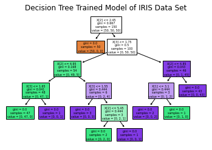

```python
from sklearn.tree import DecisionTreeClassifier
from sklearn.tree import plot_tree

model = DecisionTreeClassifier().fit(X,y)
plot_tree(model, filled=True)
plt.title('Decision Tree Trained Model of IRIS Data Set')
plt.savefig('decision_tree_tiff.tiff',dpi=300)
plt.show()
```

Spliting Data Set Into Test and Train. Testing Dataset value will be (20%,30%,10%)

```python
from sklearn.model_selection import train_test_split
x_train,x_test, y_train,y_test = train_test_split(X,y, test_size=0.2,random_state=0)
x1_train,x1_test, y1_train,y1_test = train_test_split(X,y, test_size=0.3,random_state=0)
x2_train,x2_test, y2_train,y2_test = train_test_split(X,y, test_size=0.1,random_state=0)
```

## Now we will Train our Model

```python
from sklearn import tree
model = tree.DecisionTreeClassifier().fit(X,y)
model
```

```
DecisionTreeClassifier()
```

**Predicting x_test values**

```python
predicted_xtest= model.predict(x_test)
predicted_xtest
```

```
array(['virginica', 'versicolor', 'setosa', 'virginica', 'setosa',
       'virginica', 'setosa', 'versicolor', 'versicolor', 'versicolor',
       'virginica', 'versicolor', 'versicolor', 'versicolor',
       'versicolor', 'setosa', 'versicolor', 'versicolor', 'setosa',
       'setosa', 'virginica', 'versicolor', 'setosa', 'setosa',
       'virginica', 'setosa', 'setosa', 'versicolor', 'versicolor',
       'setosa'], dtype=object)
```

```python
predicted_x1_test= model.predict(x1_test)
predicted_x1_test
```

```
array(['virginica', 'versicolor', 'setosa', 'virginica', 'setosa',
       'virginica', 'setosa', 'versicolor', 'versicolor', 'versicolor',
       'virginica', 'versicolor', 'versicolor', 'versicolor',
       'versicolor', 'setosa', 'versicolor', 'versicolor', 'setosa',
       'setosa', 'virginica', 'versicolor', 'setosa', 'setosa',
       'virginica', 'setosa', 'setosa', 'versicolor', 'versicolor',
       'setosa', 'virginica', 'versicolor', 'setosa', 'virginica',
       'virginica', 'versicolor', 'setosa', 'versicolor', 'versicolor',
       'versicolor', 'virginica', 'setosa', 'virginica', 'setosa',
       'setosa'], dtype=object)
```

```python
predicted_x2_test= model.predict(x2_test)
predicted_x2_test
```

```
array(['virginica', 'versicolor', 'setosa', 'virginica', 'setosa',
       'virginica', 'setosa', 'versicolor', 'versicolor', 'versicolor',
       'virginica', 'versicolor', 'versicolor', 'versicolor',
       'versicolor'], dtype=object)
```

## **Accuracy Score**

```python
from sklearn.metrics import accuracy_score
accu_score = accuracy_score(y_test,predicted_xtest)
accu_score
```

```
1.0
```

```python
accu_score2 = accuracy_score(y1_test,predicted_x1_test)
accu_score3 = accuracy_score(y2_test,predicted_x2_test)
print(accu_score2,accu_score3)
```

```
1.0 1.0
```

**Predicting Un-known Random Values**

```python
predicted_unkonw1 = model.predict([[2.0,3.0,2.4,0.3]]) # Un-Known Value One
predicted_unkonw2 = model.predict([[10,6.0,1.4,0.5]]) # Un-known value two
predicted_unkonw3 = model.predict([[12,4.0,1.6,0.7]]) # Unknown value Three
predicted_unkonw4 = model.predict([[2.9,6.0,1.8,3.0]]) # Unknown Value Four
predicted_unkonw5 = model.predict([[1.0,4.0,1.4,2]]) # Unknown Value Five
print(predicted_unkonw1,predicted_unkonw2,predicted_unkonw3,predicted_unkonw4,predicted_unkonw5)
```

```
['setosa'] ['setosa'] ['setosa'] ['setosa'] ['setosa']
```

```python
score = model.score(x_test,y_test)
score1= model.score(x1_test,y1_test)
score2= model.score(x2_test,y2_test)
print(score,score1,score2)
```

```
1.0 1.0 1.0
```

```python
model.score(x_test,p)
```

# 11- Random Forest Calssifier

```python
import pandas as pd
import numpy as np
import seaborn as sns
import matplotlib.pyplot as plt
```

### Loading Data-Set

```python
df=sns.load_dataset('iris')
df.head()
```

|  | sepal_length | sepal_width | petal_length | petal_width | species |
| --- | --- | --- | --- | --- | --- |
| 0 | 5.1 | 3.5 | 1.4 | 0.2 | setosa |
| 1 | 4.9 | 3.0 | 1.4 | 0.2 | setosa |
| 2 | 4.7 | 3.2 | 1.3 | 0.2 | setosa |
| 3 | 4.6 | 3.1 | 1.5 | 0.2 | setosa |
| 4 | 5.0 | 3.6 | 1.4 | 0.2 | setosa |

## Selecting Data-set

```python
import matplotlib.pyplot as plt
from sklearn.tree import  DecisionTreeClassifier
X = df.iloc[:,:-1]
y = df.iloc[:,-1:]
```

```python
X.head()
```

|  | sepal_length | sepal_width | petal_length | petal_width |
| --- | --- | --- | --- | --- |
| 0 | 5.1 | 3.5 | 1.4 | 0.2 |
| 1 | 4.9 | 3.0 | 1.4 | 0.2 |
| 2 | 4.7 | 3.2 | 1.3 | 0.2 |
| 3 | 4.6 | 3.1 | 1.5 | 0.2 |
| 4 | 5.0 | 3.6 | 1.4 | 0.2 |

```python
y.head()
```

|  | species |
| --- | --- |
| 0 | setosa |
| 1 | setosa |
| 2 | setosa |
| 3 | setosa |
| 4 | setosa |

## Creating a Model

```python
from sklearn.ensemble import RandomForestClassifier
from sklearn.tree import plot_tree

model = RandomForestClassifier(n_estimators=100)
model.fit(X,y)
```

```
RandomForestClassifier()
```

## What is n_estimators.

This is the number of trees you want to build before taking the maximum voting or averages of predictions. Higher number of trees give you better performance but makes your code slower.

## Model Prediction

```python
predicted_value = model.predict([[5,2,3,6]])
predicted_value
```

```
array(['virginica'], dtype=object)
```

## Spliting Data Set

```python
from sklearn.model_selection import train_test_split
x_train,x_test,y_train,y_test = train_test_split(X,y,test_size=0.2)
```

## Predicting x_Test

```python
predicted_xtest = model.predict(x_test)
predicted_xtest
```

```
array(['versicolor', 'versicolor', 'virginica', 'versicolor', 'setosa',
       'versicolor', 'setosa', 'virginica', 'virginica', 'versicolor',
       'setosa', 'versicolor', 'virginica', 'virginica', 'virginica',
       'versicolor', 'setosa', 'versicolor', 'setosa', 'setosa', 'setosa',
       'setosa', 'setosa', 'versicolor', 'setosa', 'virginica', 'setosa',
       'virginica', 'virginica', 'versicolor'], dtype=object)
```

## Accuracy test

```python
score = model.score(x_test,y_test)
print("Accuracy Score of our Model is:",score)
```

```
Accuracy Score of our Model is: 1.0
```

```python
from sklearn import metrics
print ("Accuracy",metrics.accuracy_score(y_test,predicted_xtest))
```

```
Accuracy 1.0
```

## Confusion Metrics

```python
cm = metrics.confusion_matrix(y_test,predicted_xtest)
cm
```

```
array([[11,  0,  0],
       [ 0, 10,  0],
       [ 0,  0,  9]], dtype=int64)
```

## PLOTTING A GRAPH

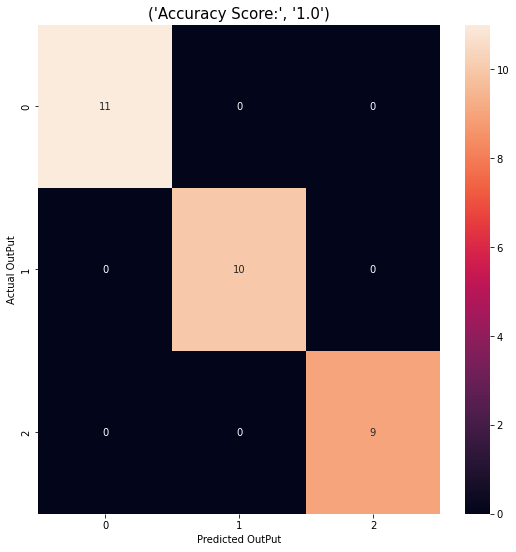

```python
plt.figure(figsize=(9,9))
sns.heatmap(cm, annot=True)
plt.ylabel('Actual OutPut')
plt.xlabel('Predicted OutPut')
all_sample_title = "Accuracy Score:",format(score)
plt.title(all_sample_title,size=15)
```

## Random Forest Reggressor

```python
import pandas as pd
import numpy as np
import seaborn as sns
import matplotlib.pyplot as plt
```

### Loading Data-Set

```python
df=pd.read_csv('mldata.csv')
df.head()
```

|  | age | height | weight | gender | likeness |
| --- | --- | --- | --- | --- | --- |
| 0 | 27 | 170.688 | 76.0 | Male | Biryani |
| 1 | 41 | 165.000 | 70.0 | Male | Biryani |
| 2 | 29 | 171.000 | 80.0 | Male | Biryani |
| 3 | 27 | 173.000 | 102.0 | Male | Biryani |
| 4 | 29 | 164.000 | 67.0 | Male | Biryani |

Changing Ctegorical Values With Numerical Value

```python
df["gender"]= df["gender"].replace("Male",0.0)
df["gender"]= df["gender"].replace("Female",1.0)
df["likeness"]= df["likeness"].replace("Biryani",2.0)
df["likeness"]= df["likeness"].replace("Samosa",3.0)
df["likeness"]= df["likeness"].replace("Pakora",4.0)
```

## Selecting Data-set

```python
import matplotlib.pyplot as plt
from sklearn.tree import  DecisionTreeClassifier
X = df.iloc[:,:-2]
y = df.iloc[:,-2]
```

```python
X.head()
```

|  | age | height | weight |
| --- | --- | --- | --- |
| 0 | 27 | 170.688 | 76.0 |
| 1 | 41 | 165.000 | 70.0 |
| 2 | 29 | 171.000 | 80.0 |
| 3 | 27 | 173.000 | 102.0 |
| 4 | 29 | 164.000 | 67.0 |

```python
y.tail()
```

[output not shown]

## Creating a Model

```python
from sklearn.ensemble import  RandomForestRegressor
from sklearn.datasets import make_regression
make_regression (n_features=4,n_informative=2,random_state=0,shuffle=False)
# X,y = make_regression(n_features=4, n_informative=2,random_state=0,shuffle=False)
model = RandomForestRegressor(max_depth=2,random_state=0)
model.fit(X,y)
```

```
RandomForestRegressor(max_depth=2, random_state=0)
```

```python
model.predict([[27,170.688,76.0,]])
```

```
array([0.02144861])
```

## Spliting Data Set

```python
from sklearn.model_selection import train_test_split
x_train,x_test,y_train,y_test = train_test_split(X,y,test_size=0.2)
```

## Predicting x_Test

```python
predicted_xtest = model.predict(x_test)
predicted_xtest
```

```
array([0.36181381, 0.07386671, 0.36210821, 0.17595025, 0.07404747,
       0.22450609, 0.13987047, 0.07289897, 0.02572788, 0.02572788,
       0.02144861, 0.08594599, 0.02493558, 0.02259179, 0.3322361 ,
       0.08525633, 0.02162405, 0.08594599, 0.02328677, 0.77235201,
       0.23772239, 0.02659297, 0.21284877, 0.02259179, 0.0234622 ,
       0.19903605, 0.07289897, 0.02746339, 0.20172568, 0.08194481,
       0.02562523, 0.02144861, 0.08594599, 0.02144861, 0.07317705,
       0.23063438, 0.02144861, 0.02259179, 0.02144861, 0.23059107,
       0.33114366, 0.02259179, 0.02241635, 0.09416975, 0.36386055,
       0.02259179, 0.02162405, 0.08778414, 0.08594599])
```

## Accuracy test

```python
score = model.score(x_test,y_test)
print("Accuracy Score of our Model is:",score)
```

```
Accuracy Score of our Model is: 0.2890422143252166
```

# Machine Learning

## 12-Polynomial Reggression

```python
# Import Libraries
import numpy as np
import matplotlib.pyplot as plt
import seaborn as sns
```

```python
x = [89,43,36,36,95,10,66,34,38,20,26,29,48,64,6,5,36,66,72,40]
y = [21,46,3,35,67,95,53,72,58,10,26,34,90,33,38,20,56,2,47,15]
```

Example of Bad Fit

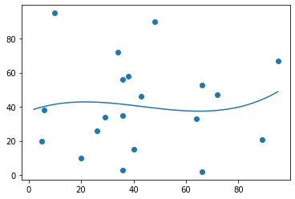

```python
mymodel = numpy.poly1d(numpy.polyfit(x,y,3))
myline = np.linspace(2,95,100)
plt.scatter(x,y)
plt.plot(myline,mymodel(myline))
plt.show()
```

```python
from sklearn.metrics import r2_score
model = numpy.poly1d(numpy.polyfit(x,y,3))
print(r2_score(y,model(x)))
```

```
0.009952707566680541
```

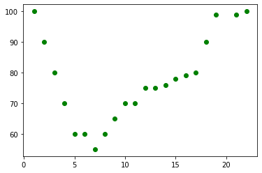

```python
x = [1,2,3,4,5,6,7,8,9,10,11,12,13,14,15,16,17,18,19,21,22]
y = [100,90,80,70,60,60,55,60,65,70,70,75,75,76,78,79,80,90,99,99,100]
plt.scatter(x,y, color ="green")
plt.show()
```

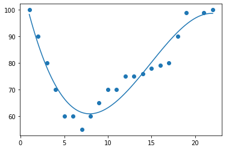

```python
mymodel = numpy.poly1d(numpy.polyfit(x,y,3))
myline = numpy.linspace(1,22,100)
plt.scatter(x,y)
plt.plot(myline,mymodel(myline))
plt.show()
```

Finding R-Sauared

```python
x = [1,2,3,4,5,6,7,8,9,10,11,12,13,14,15,16,17,18,19,21,22]
y = [100,90,80,70,60,60,55,60,65,70,70,75,75,76,78,79,80,90,99,99,100]
mymodel = numpy.poly1d(numpy.polyfit(x,y,3))
print(r2_score(y,mymodel(x)))
```

```
0.9105828652909624
```

Pridiction

```python
speed = mymodel(18)
print(speed)
```

```
91.63642307349389
```

## Exaple on Amazon Online Dataset

```python
import pandas as pd
dataset = pd.read_csv("https://s3.us-west-2.amazonaws.com/public.gamelab.fun/dataset/position_salaries.csv")
```

```python
dataset.head()
```

|  | Position | Level | Salary |
| --- | --- | --- | --- |
| 0 | Business Analyst | 1 | 45000 |
| 1 | Junior Consultant | 2 | 50000 |
| 2 | Senior Consultant | 3 | 60000 |
| 3 | Manager | 4 | 80000 |
| 4 | Country Manager | 5 | 110000 |

```python
X = dataset.iloc[:, 1:2].values
y = dataset.iloc[:, 2].values
```

```python
X
```

```
array([[ 1],
       [ 2],
       [ 3],
       [ 4],
       [ 5],
       [ 6],
       [ 7],
       [ 8],
       [ 9],
       [10]], dtype=int64)
```

Splitting Dataset into the Training set and Test Set

```python
from sklearn.model_selection import train_test_split
x_train,x_test,y_train,y_test = train_test_split(X,y, test_size = 0.2, random_state=0)
```

Fitting Linear Regression To the Data-Set

```python
from sklearn.linear_model import  LinearRegression
lin_reg = LinearRegression()
lin_reg.fit(X,y)
```

```
LinearRegression()
```

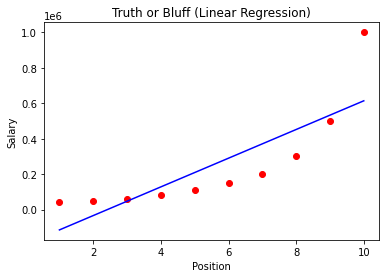

```python
# Visualizing The Linear Regression Result

def viz_linear():
    plt.scatter(X,y, color="red")
    plt.plot(X,lin_reg.predict(X), Color = 'blue')
    plt.title("Truth or Bluff (Linear Regression)")
    plt.xlabel("Position")
    plt.ylabel("Salary")
    plt.show()
    return

viz_linear()
```

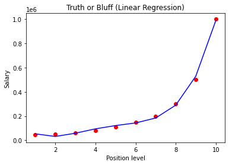

```python
from sklearn.preprocessing import PolynomialFeatures
poly_reg = PolynomialFeatures(degree=4)
X_poly = poly_reg.fit_transform(X)
pol_reg = LinearRegression()
pol_reg.fit(X_poly,y)

def viz_polynomial():
    plt.scatter(X,y, color="red")
    plt.plot(X,pol_reg.predict(poly_reg.fit_transform(X)), Color = 'blue')
    plt.title("Truth or Bluff (Linear Regression)")
    plt.xlabel("Position level")
    plt.ylabel("Salary")
    plt.show()
    return

viz_polynomial()
```

Predicting New result With Linear Regresion

```python
pred_linear = lin_reg.predict([[15]])
pred_linear
```

```
array([1017848.48484848])
```

Predicting New Result With Polynomial Regression

```python
pred_polynomial= pol_reg.predict(poly_reg.fit_transform([[5.5]]))
pred_polynomial
```

```
array([132148.43750003])
```

```python
print("Linear Regression Result is =",pred_linear)
print("Ploynomial Regression Result is =",pred_polynomial)
print(" Difference  is =",pred_linear - pred_polynomial)
```

```
Linear Regression Result is = [1017848.48484848]
Ploynomial Regression Result is = [132148.43750003]
 Difference  is = [885700.04734845]
```

## 13- NAIVE BAYES

```python
# Importing Libraries
import pandas as pd
import numpy as np
import matplotlib.pyplot as plt
import seaborn as sns
```

Load Data-Set

```python
phool = sns.load_dataset("iris")
phool.head()
```

|  | sepal_length | sepal_width | petal_length | petal_width | species |
| --- | --- | --- | --- | --- | --- |
| 0 | 5.1 | 3.5 | 1.4 | 0.2 | setosa |
| 1 | 4.9 | 3.0 | 1.4 | 0.2 | setosa |
| 2 | 4.7 | 3.2 | 1.3 | 0.2 | setosa |
| 3 | 4.6 | 3.1 | 1.5 | 0.2 | setosa |
| 4 | 5.0 | 3.6 | 1.4 | 0.2 | setosa |

Selecting Data Set

```python
X = phool.iloc[:,:-1]
y = phool.iloc[: ,-1:]
```

```python
X.head()
```

|  | sepal_length | sepal_width | petal_length | petal_width |
| --- | --- | --- | --- | --- |
| 0 | 5.1 | 3.5 | 1.4 | 0.2 |
| 1 | 4.9 | 3.0 | 1.4 | 0.2 |
| 2 | 4.7 | 3.2 | 1.3 | 0.2 |
| 3 | 4.6 | 3.1 | 1.5 | 0.2 |
| 4 | 5.0 | 3.6 | 1.4 | 0.2 |

```python
y.head()
```

|  | species |
| --- | --- |
| 0 | setosa |
| 1 | setosa |
| 2 | setosa |
| 3 | setosa |
| 4 | setosa |

Traing And fitting the Model

```python
from sklearn.naive_bayes import GaussianNB
model = GaussianNB().fit(X,y)
model
```

```
GaussianNB()
```

Traing and Splitting Tha Data Set

```python
from sklearn.model_selection import  train_test_split
x_train,x_test,y_train,y_test = train_test_split(X,y,test_size=0.2,random_state=0)
```

Training The Model on Training Set

```python
from sklearn.naive_bayes import GaussianNB
model = GaussianNB().fit(x_train,y_train)
# Making prediction on the testing set
y_pred = model.predict(x_test)
y_pred
```

```
array(['virginica', 'versicolor', 'setosa', 'virginica', 'setosa',
       'virginica', 'setosa', 'versicolor', 'versicolor', 'versicolor',
       'versicolor', 'versicolor', 'versicolor', 'versicolor',
       'versicolor', 'setosa', 'versicolor', 'versicolor', 'setosa',
       'setosa', 'virginica', 'versicolor', 'setosa', 'setosa',
       'virginica', 'setosa', 'setosa', 'versicolor', 'versicolor',
       'setosa'], dtype='<U10')
```

Accuracy Score Check

```python
from sklearn import metrics
score = metrics.accuracy_score(y_test,y_pred)
print("Gussian Nive Bayes Model Accuracy (in %):",metrics.accuracy_score(y_test,y_pred))
```

```
Gussian Nive Bayes Model Accuracy (in %): 0.9666666666666667
```

```python
from sklearn import  metrics
cm = metrics.confusion_matrix(y_test,y_pred)
cm
```

```
array([[11,  0,  0],
       [ 0, 13,  0],
       [ 0,  1,  5]], dtype=int64)
```

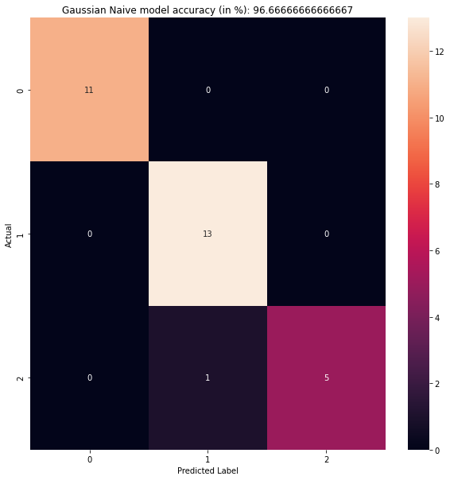

```python
plt.figure(figsize=(10,10))
sns.heatmap(cm,annot=True)
plt.ylabel("Actual")
plt.xlabel("Predicted Label")
all_sample_title = "Gaussian Naive model accuracy (in %): {0}".format(score*100)
plt.title(all_sample_title)
```

# Machine Learning

## 13 -SUPPORT VECTOR MACHINE

Importing & Loading Datasets

```python
# import Scikit-learn Data set library

from sklearn import datasets

cancer = datasets.load_breast_cancer()
```

Print Cancer datset Feature Name

```python
print("Features:",cancer.feature_names)
```

```
Features: ['mean radius' 'mean texture' 'mean perimeter' 'mean area'
 'mean smoothness' 'mean compactness' 'mean concavity'
 'mean concave points' 'mean symmetry' 'mean fractal dimension'
 'radius error' 'texture error' 'perimeter error' 'area error'
 'smoothness error' 'compactness error' 'concavity error'
 'concave points error' 'symmetry error' 'fractal dimension error'
 'worst radius' 'worst texture' 'worst perimeter' 'worst area'
 'worst smoothness' 'worst compactness' 'worst concavity'
 'worst concave points' 'worst symmetry' 'worst fractal dimension']
```

print The label type of the cancer ("Malignent "benign) Labels is equal to y value

```python
print("labels :",cancer.target_names)
```

```
labels : ['malignant' 'benign']
```

```python
cancer.data.shape
```

```
(569, 30)
```

```python
print(cancer.data[0:5])
```

```
[[1.799e+01 1.038e+01 1.228e+02 1.001e+03 1.184e-01 2.776e-01 3.001e-01
  1.471e-01 2.419e-01 7.871e-02 1.095e+00 9.053e-01 8.589e+00 1.534e+02
  6.399e-03 4.904e-02 5.373e-02 1.587e-02 3.003e-02 6.193e-03 2.538e+01
  1.733e+01 1.846e+02 2.019e+03 1.622e-01 6.656e-01 7.119e-01 2.654e-01
  4.601e-01 1.189e-01]
 [2.057e+01 1.777e+01 1.329e+02 1.326e+03 8.474e-02 7.864e-02 8.690e-02
  7.017e-02 1.812e-01 5.667e-02 5.435e-01 7.339e-01 3.398e+00 7.408e+01
  5.225e-03 1.308e-02 1.860e-02 1.340e-02 1.389e-02 3.532e-03 2.499e+01
  2.341e+01 1.588e+02 1.956e+03 1.238e-01 1.866e-01 2.416e-01 1.860e-01
  2.750e-01 8.902e-02]
 [1.969e+01 2.125e+01 1.300e+02 1.203e+03 1.096e-01 1.599e-01 1.974e-01
  1.279e-01 2.069e-01 5.999e-02 7.456e-01 7.869e-01 4.585e+00 9.403e+01
  6.150e-03 4.006e-02 3.832e-02 2.058e-02 2.250e-02 4.571e-03 2.357e+01
  2.553e+01 1.525e+02 1.709e+03 1.444e-01 4.245e-01 4.504e-01 2.430e-01
  3.613e-01 8.758e-02]
 [1.142e+01 2.038e+01 7.758e+01 3.861e+02 1.425e-01 2.839e-01 2.414e-01
  1.052e-01 2.597e-01 9.744e-02 4.956e-01 1.156e+00 3.445e+00 2.723e+01
  9.110e-03 7.458e-02 5.661e-02 1.867e-02 5.963e-02 9.208e-03 1.491e+01
  2.650e+01 9.887e+01 5.677e+02 2.098e-01 8.663e-01 6.869e-01 2.575e-01
  6.638e-01 1.730e-01]
 [2.029e+01 1.434e+01 1.351e+02 1.297e+03 1.003e-01 1.328e-01 1.980e-01
  1.043e-01 1.809e-01 5.883e-02 7.572e-01 7.813e-01 5.438e+00 9.444e+01
  1.149e-02 2.461e-02 5.688e-02 1.885e-02 1.756e-02 5.115e-03 2.254e+01
  1.667e+01 1.522e+02 1.575e+03 1.374e-01 2.050e-01 4.000e-01 1.625e-01
  2.364e-01 7.678e-02]]
```

```python
# Print the Cancer labels (0:malignant,1:benign)
print(cancer.target)
```

```
[0 0 0 0 0 0 0 0 0 0 0 0 0 0 0 0 0 0 0 1 1 1 0 0 0 0 0 0 0 0 0 0 0 0 0 0 0
 1 0 0 0 0 0 0 0 0 1 0 1 1 1 1 1 0 0 1 0 0 1 1 1 1 0 1 0 0 1 1 1 1 0 1 0 0
 1 0 1 0 0 1 1 1 0 0 1 0 0 0 1 1 1 0 1 1 0 0 1 1 1 0 0 1 1 1 1 0 1 1 0 1 1
 1 1 1 1 1 1 0 0 0 1 0 0 1 1 1 0 0 1 0 1 0 0 1 0 0 1 1 0 1 1 0 1 1 1 1 0 1
 1 1 1 1 1 1 1 1 0 1 1 1 1 0 0 1 0 1 1 0 0 1 1 0 0 1 1 1 1 0 1 1 0 0 0 1 0
 1 0 1 1 1 0 1 1 0 0 1 0 0 0 0 1 0 0 0 1 0 1 0 1 1 0 1 0 0 0 0 1 1 0 0 1 1
 1 0 1 1 1 1 1 0 0 1 1 0 1 1 0 0 1 0 1 1 1 1 0 1 1 1 1 1 0 1 0 0 0 0 0 0 0
 0 0 0 0 0 0 0 1 1 1 1 1 1 0 1 0 1 1 0 1 1 0 1 0 0 1 1 1 1 1 1 1 1 1 1 1 1
 1 0 1 1 0 1 0 1 1 1 1 1 1 1 1 1 1 1 1 1 1 0 1 1 1 0 1 0 1 1 1 1 0 0 0 1 1
 1 1 0 1 0 1 0 1 1 1 0 1 1 1 1 1 1 1 0 0 0 1 1 1 1 1 1 1 1 1 1 1 0 0 1 0 0
 0 1 0 0 1 1 1 1 1 0 1 1 1 1 1 0 1 1 1 0 1 1 0 0 1 1 1 1 1 1 0 1 1 1 1 1 1
 1 0 1 1 1 1 1 0 1 1 0 1 1 1 1 1 1 1 1 1 1 1 1 0 1 0 0 1 0 1 1 1 1 1 0 1 1
 0 1 0 1 1 0 1 0 1 1 1 1 1 1 1 1 0 0 1 1 1 1 1 1 0 1 1 1 1 1 1 1 1 1 1 0 1
 1 1 1 1 1 1 0 1 0 1 1 0 1 1 1 1 1 0 0 1 0 1 0 1 1 1 1 1 0 1 1 0 1 0 1 0 0
 1 1 1 0 1 1 1 1 1 1 1 1 1 1 1 0 1 0 0 1 1 1 1 1 1 1 1 1 1 1 1 1 1 1 1 1 1
 1 1 1 1 1 1 1 0 0 0 0 0 0 1]
```

Spliting data Set into Test and Train

```python
from sklearn.model_selection import train_test_split
x_train , x_test , y_train, y_test = train_test_split(cancer.data, cancer.target, test_size=0.2, random_state=0)
```

Selecting And Creating Model

```python
from sklearn import svm
# Creat SVM Classifier
clf = svm.SVC(kernel="linear")

clf.fit(x_train, y_train)

# Predict The response for the dataset
predictions = clf.predict(x_test)
```

Accuracy Check

```python
from sklearn import metrics
score = metrics.accuracy_score(y_test,predictions)
print("Precision:",metrics.precision_score(y_test,predictions))
```

```
Precision: 0.984375
```

```python
print("recall:",metrics.recall_score(y_test,predictions))
```

```
recall: 0.9402985074626866
```

Confusion Metrics

```python
from sklearn import metrics
cm = metrics.confusion_matrix(y_test,predictions)
cm
```

```
array([[46,  1],
       [ 4, 63]], dtype=int64)
```

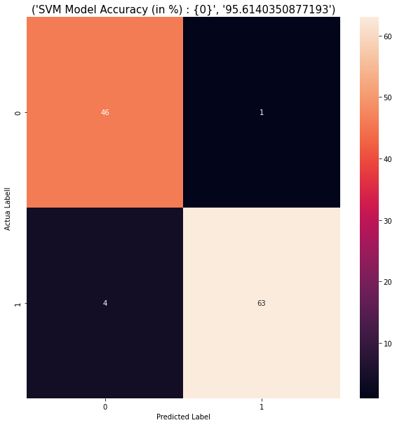

```python
import matplotlib.pyplot as plt
import seaborn as sns
plt.figure(figsize=(10,10))
sns.heatmap(cm,annot=True)
plt.ylabel("Actua Labell")
plt.xlabel("Predicted Label")
all_sample_title = "SVM Model Accuracy (in %) : {0}",format(score*100)
plt.title(all_sample_title, size = 15)
```